# **Distinct Elements**

We’ve seen how to apply linearity of variance and Chebyshev’s inequality to the distinct elements problem. In this class, we will see how to apply these tools to the load balancing problem.

Our goal is to ensure that requests are distributed evenly, so no one server gets loaded with too many requests. We want to avoid downtime and slow responses to clients.

Why should we use a hash function instead of just distributing requests randomly? Well, if a query has already been answered on a server, we want to direct the same query to it again so we don’t have to recompute the same answer on different servers.

Suppose we have $n$ servers and $m$ requests $x_1, \ldots, x_m$. Let $s_i$ be the number of requests sent to server $i \in \{1, \ldots, n\}$. Formally,
$$s_i = \sum_{j=1}^m \mathbb{1}[h(x_j)=1].$$
Our goal is to understand the value of the maximum load on any server, which can be written as the random variable
$$S = \max_{i \in \{1, \ldots, n\}} s_i.$$

A good first step in any analysis of random variables is to think about expectations. If we have $n$ servers and $m$ requests, for any $i \in \{1, \ldots, n\}$,
$$\mathbb{E}[s_i] = \sum_{j=1}^m
\mathbb{E}\left[\mathbb{1}[h(x_j)=1]\right]
= \frac{m}{n}.$$
But it’s very unclear what the expectation of $S$ is. In particular, $\mathbb{E}[S] \neq \max_{i \in \{1, \ldots, n\}} \mathbb{E}[s_i]$.

Can you convince yourself that for two random variables $A$ and $B$, $\mathbb{E}[\max(A,B)] \neq \max(\mathbb{E}[A], \mathbb{E}[B])$? One example to think about is when $A$ and $B$ are independent variables that are each equally likely to be $1$ and $0$.

In order to reduce notation and keep the math simple, let’s assume that $m=n$. That is, we assume that we have exactly the same number of servers and requests. As we did in the last problem, we’ll continue to assume we have access to a uniformly random hash function $h$ so that $\Pr(h(x) = h(y))=\frac{1}{m}$.

We can visualize the load balancing problem in the following figure: Each request is placed in a server uniformly and at random.

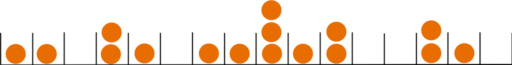

We know that the expected number of requests per server is $\mathbb{E}[s_i] = \frac{m}{n} = 1$ under our assumption that we have the same number of requests and servers. We would like to prove
$$\Pr\left(
\max_{i} s_i \geq C
\right) \leq \frac{1}{10}$$
where $C$ is a small value (much smaller than $n$). Putting it another way, we would like to prove
$$\Pr\left( (s_1 \geq C) \cup (s_2 \geq C) \cup \ldots \cup (s_n \geq
C)\right)
\leq \frac{1}{10}.$$
Notice these statements are equivalent since the max is greater than $C$ if at least one of the values is greater than $C$.

Whenever we look at the union of different events, we should immediately think of the union bound! Recall that the union bound allows us to nicely upper bound the union of events even when the events have complicated and dependent dynamics.

### Union Bound

**Union Bound:** For any events $A_1, \ldots, A_n$,
$$\Pr(A_1 \cup \ldots \cup A_n) \leq \Pr(A_1) + \ldots + \Pr(A_n).$$

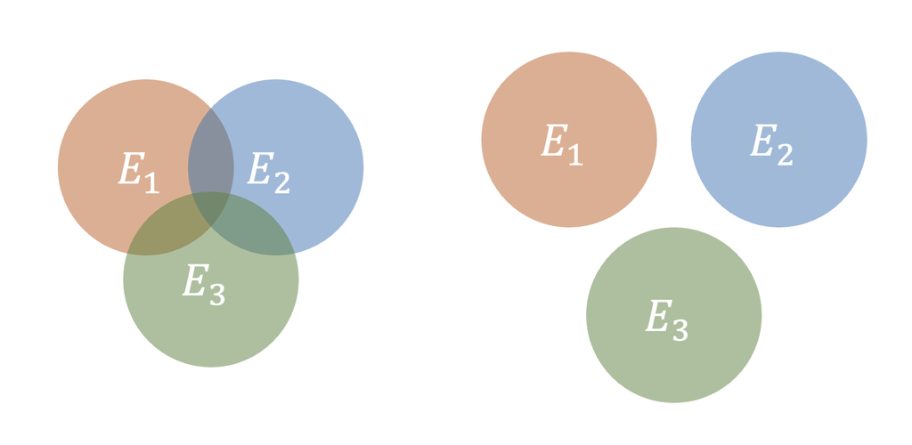

We saw the proof by picture last class. This time, we’ll prove the union bound using Markov’s inequality. Ironically, three of the tools that we’ve used so far (Markov’s inequality, Chebyshev’s inequality, and the union bound) are all Markov’s inequality.

**Proof**: Let $X_i = \mathbb{1}[A_i]$ be the indicator random variable that event $A_i$ occurs. Define $S= \sum_{i=1}^n X_i$ as the number of events that occur. Markov’s inequality tells us that
$$\Pr \left( A_1 \cup \ldots \cup A_n \right)
= \Pr \left( \sum_{i=1}^n X_i \geq 1 \right)
\leq \mathbb{E}[S]$$
$$= \sum_{i=1}^n \mathbb{E}[X_i]
= \Pr(A_1) + \ldots + \Pr(A_n).$$

It should look hard to prove $\Pr(s_i \geq C) \leq \frac{1}{10n}$. This implies that $s_i < C$ for a particular server $i$ with *very high* probabiity $1- \frac{1}{10n}$. Unfortunately, Markov’s inequality is too weak for this. We’ll instead use Chebyshev’s inequality but we’ll first have to understand the variance $\textrm{Var}(s_i) = \sigma^2$. Let $s_{i,j}$ be the indicator random variable that the $j$th request goes to the $i$th server. We have
$$s_i = \sum_{j=1}^n s_{i,j}.$$
Since each $s_{i,j}$ and $s_{i,j'}$ are independent, we can apply linearity of variance and get
$$\textrm{Var}(s_i)
=\sum_{j=1}^n \textrm{Var}(s_i,j).$$
We know that server $i$ gets request $j$ with probability $\frac{1}{n}$ so $s_i = 1$ with probability $\frac{1}{n}$ and $s_i=0$ otherwise. This tells us that $\mathbb{E}[s_{i,j}] = \frac{1}{n}$ and $\mathbb{E}[s_{i,j}^2] = \frac{1}{n}$. Then
$$\textrm{Var}(s_{i,j}) = \frac{1}{n} - \frac{1}{n^2} \leq \frac{1}{n}$$
and
$$\textrm{Var}(s_i) \leq n \frac{1}{n} = 1.$$
Similarly, we know $\mathbb{E}[s_i] = 1$.

Applying Chebyshev’s inequality gives
$$\Pr\left(
|s_i - 1| \geq k
\right)
\leq \frac{1}{k^2}.$$

Setting $k=\sqrt{10n}$ gives
$$\Pr(|s_i - 1| \geq \sqrt{10n}) \leq \frac{1}{10n}
\implies
\Pr(s_i \geq \sqrt{10n}+1) \leq \frac{1}{10n}$$
By the union bound argument from before, we have
$$\Pr \left(
\max_{i \in \{1, \ldots, n\}} s_i \geq \sqrt{10n} + 1
\right)
\leq \frac{1}{10}.$$

In words, we proved that when hashing $n$ requests into $n$ servers, the server with the maximum number of requests contains no more than $\sqrt{10n} + 1$ requests with probability $\frac{9}{10}$.

## Conclusion

In this class, we analyzed and solved the distinct elements problem and the load balancing problem. Both are important and widely applicable. But the real value of what we did today is not the specific problems we solved but the techniques we used to solve them:

- We used the union bound to control the maximum of many random variables.
- We used Chebyshev’s inequality to bound a variable whose variance we could can compute.
- In order to compute the variance, we took a random variable and decomposed it into a sum of independent random variables so that we could apply linearity of variance.